# The Network of COVID-19 Contagion in Italy

2026-02-07

## Introduction

Traditional epidemic analysis focuses on the volume of cases. This project shifts the perspective to a **network of synchronization**. We define provinces as connected if their **acceleration/deceleration trends** are highly correlated.

**Objective:** Analyze the First Wave (Spring 2020) in Italy to understand the hidden structure of the contagion.

**Research Questions:**

- **Q1 (Topology):** Is the network scale-free?
- **Q2 (Evolution):** How did synchronization change between the strict Lockdown and the Reopening?
- **Q3 (Communities):** Do infection clusters respect administrative regions?
- **Q4 (Resilience):** How robust is the network to the removal of “hub” provinces?

## Methodology: Data Preparation

We use COVID-19 province-level infection data from the Dipartimento di Protezione Civile. The key metric is the **daily growth rate** of the 7-day moving average, which makes the time series stationary and focuses on trend changes.

```r
# Load Data & Calculate Growth Rate
df <- read_csv("data/dpc-covid19-ita-province.csv")

df_clean <- df %>%
  mutate(data = ymd_hms(data)) %>%
  filter(data >= ymd("2020-02-24") & data <= ymd("2020-07-31")) %>%
  filter(!denominazione_provincia %in% c("In fase di definizione/aggiornamento",
                                         "Fuori Regione / Provincia Autonoma")) %>%
  arrange(denominazione_provincia, data) %>%
  group_by(denominazione_provincia) %>%
  mutate(
    # Fix zeros, calculate diff, smooth with 7-day MA
    nuovi_casi_ma7 = rollmean(pmax(0, totale_casi - lag(totale_casi, default=0)),
                              k = 7, fill = NA, align = "right"),
    # Log-returns for stationarity
    growth_rate = log(nuovi_casi_ma7 + 1) - log(lag(nuovi_casi_ma7) + 1)
  ) %>%
  ungroup() %>%
  filter(is.finite(growth_rate))
```

## Visual Inspection of Trends

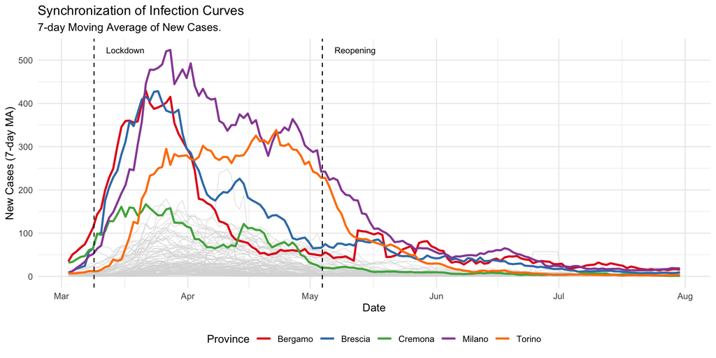

## Growth Rates

Here we visualize the **Daily Growth Rate** (log-returns of the 7-day MA). Notice how this transformation removes the “hill” shape, making the time series **stationary** (oscillating around 0). This allows us to correlate **acceleration** rather than volume.

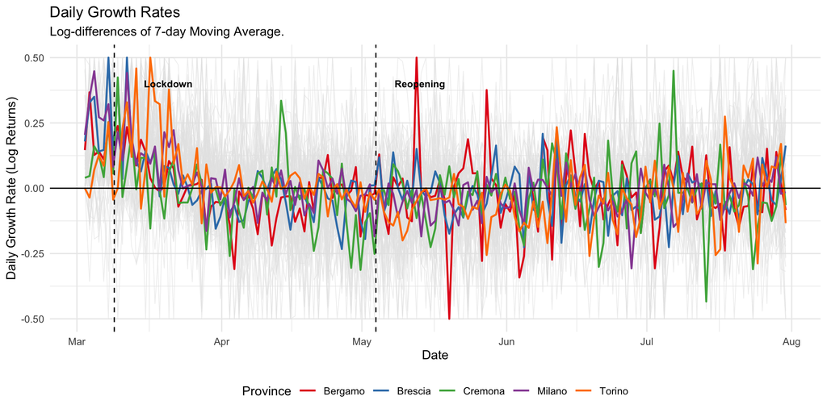

## Network Construction (The “Crisis” Network)

We build the graph based on the correlation of growth rates during the peak crisis (Feb-May).

**Threshold:** Nodes are connected if correlation \(r > 0.45\).

```r
# Filter for peak crisis
df_crisis <- df_clean %>% filter(data <= ymd("2020-05-31"))

# Pivot and Correlate
df_wide <- df_crisis %>%
  select(data, denominazione_provincia, growth_rate) %>%
  pivot_wider(names_from = denominazione_provincia, values_from = growth_rate) %>%
  select(-data)

cor_matrix <- cor(df_wide, use = "pairwise.complete.obs")
cor_matrix[lower.tri(cor_matrix, diag = TRUE)] <- NA

edges <- as.data.frame(as.table(cor_matrix)) %>%
  na.omit() %>% rename(from = Var1, to = Var2, weight = Freq) %>%
  filter(weight > 0.45)

nodes <- df_crisis %>% distinct(denominazione_provincia) %>% rename(name=1)

covid_graph <- tbl_graph(nodes = nodes, edges = edges, directed = FALSE) %>%
  activate(nodes) %>% mutate(deg = centrality_degree()) %>% filter(deg > 0)

covid_graph
```

```
## # A tbl_graph: 73 nodes and 185 edges
## #
## # An undirected simple graph with 2 components
## #
## # Node Data: 73 × 2 (active)
##    name            deg
##    <chr>         <dbl>
##  1 Agrigento         1
##  2 Alessandria       4
##  3 Ancona            8
##  4 Aosta             2
##  5 Arezzo            1
##  6 Ascoli Piceno     2
##  7 Bergamo           1
##  8 Biella            4
##  9 Bologna          18
## 10 Bolzano           4
## # ℹ 63 more rows
## #
## # Edge Data: 185 × 3
##    from    to weight
##   <int> <int>  <dbl>
## 1     2     9  0.530
## 2     3     9  0.460
## 3     1    10  0.509
## # ℹ 182 more rows
```

## Q1 — Topology: Scale-Free Property

We analyze the degree distribution. A straight line in a Log-Log plot (CCDF) indicates a Power Law (\(P(k) \sim k^{-\alpha}\)), typical of scale-free networks.

```r
d <- degree(covid_graph)

# Skewness
skewness <- function(x) mean((x - mean(x))^3) / sd(x)^3
cat("Skewness of Degree Distribution:", round(skewness(d), 2), "\n")
```

```
## Skewness of Degree Distribution: 1.66
```

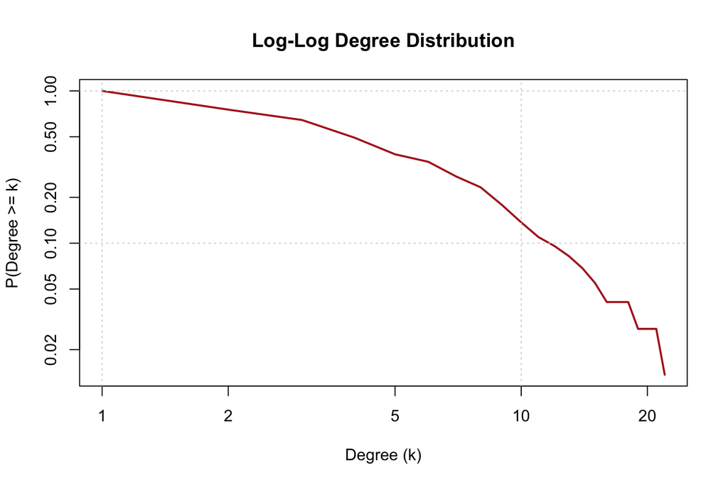

```r
# Complementary Cumulative Distribution Function
ccdf <- function(d) {
  n <- length(d); max_d <- max(d); p <- numeric(max_d)
  for (i in 1:max_d) p[i] <- sum(d >= i) / n
  return(p)
}

p_dist <- ccdf(d)
plot(1:length(p_dist), p_dist, log = "xy", type = "l", col = "firebrick", lwd = 2,
     main = "Log-Log Degree Distribution",
     xlab = "Degree (k)", ylab = "P(Degree >= k)")
grid()
```

## Q2 — Temporal Evolution: Lockdown vs Reopening

Did the “Lockdown” fragment the network or synchronize it?

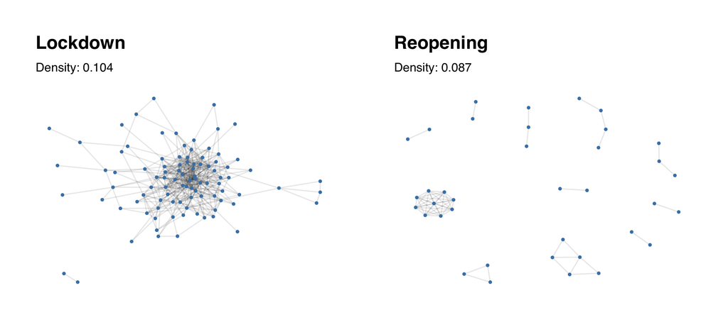

**Interpretation:** The Lockdown acted as a massive external synchronization force (“Io Resto a Casa”), bending curves in unison. Reopening led to fragmentation and localized heterogeneity.

## Q3 — Clustering: Community Detection

Using the Louvain algorithm, we detect communities of synchronization.

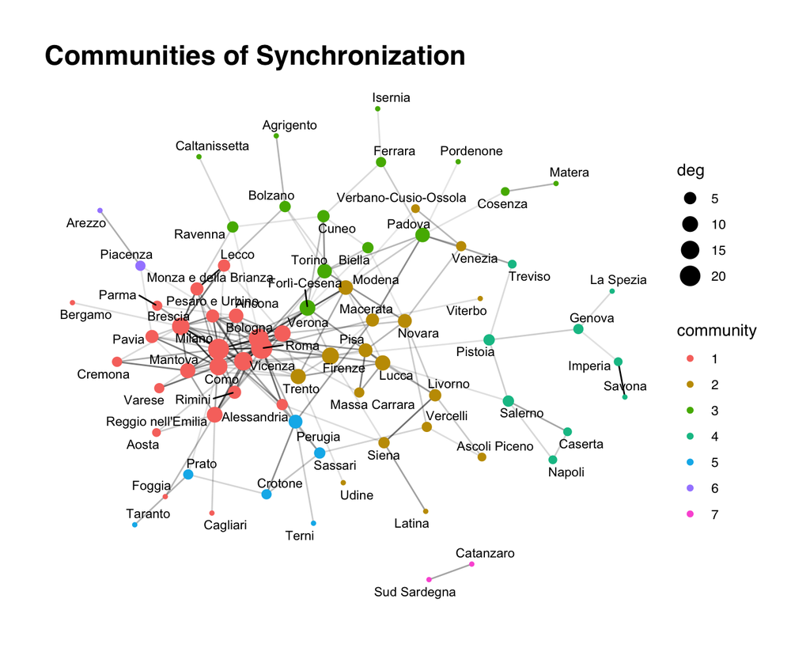

```r
covid_graph_comm <- covid_graph %>%
  activate(nodes) %>%
  mutate(community = as.factor(group_louvain()))

ggraph(covid_graph_comm, layout = "fr") +
  geom_edge_link(aes(alpha = weight), show.legend = FALSE) +
  geom_node_point(aes(color = community, size = deg)) +
  geom_node_text(aes(label = name), repel = TRUE, size = 3) +
  theme_graph(base_family = "sans") +
  labs(title = "Communities of Synchronization")
```

**Result:** Communities group geographically proximate provinces but do **not** strictly respect regional borders. Contagion dynamics follow functional lines (commuters/transport) rather than administrative ones.

## Q3.1 — The Drivers (Centrality)

Who drove the synchronization? We use **Eigenvector Centrality** to find influential nodes.

```r
covid_graph %>%
  activate(nodes) %>%
  mutate(eigen = centrality_eigen()) %>%
  as_tibble() %>%
  arrange(desc(eigen)) %>%
  select(name, eigen) %>%
  head(6) %>%
  knitr::kable(caption = "Top Synchronizers")
```

Top Synchronizers

| name | eigen |
| --- | --- |
| Roma | 1.0000000 |
| Milano | 0.9613568 |
| Bologna | 0.8656950 |
| Como | 0.7150025 |
| Vicenza | 0.7002670 |
| Brescia | 0.6646001 |

**Insight:** While Lombardy had the most cases, **Roma and Milano** were the actual network hubs. They acted as the “pulse” of the national trend, synchronizing the acceleration/deceleration across the country.

## Q4 — Resilience: Percolation Analysis

We simulate node removal: **Random Failure** vs. **Targeted Attack** (removing highest degree nodes first).

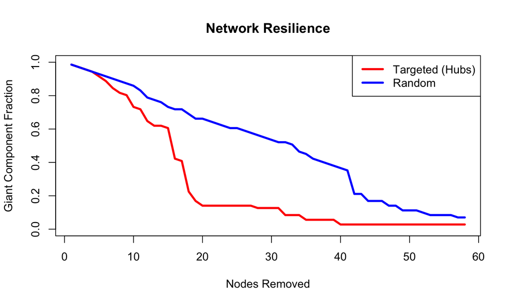

**Result:** The network is **robust to random failure** (Blue) but **extremely fragile to targeted attacks** (Red). Removing the top 20 hubs shatters the network.

## Conclusions

This network analysis provides a structural view of the First Wave in Italy.